# Homework 5

Johann Memmel

March 14, 2020

#Homework 5

```r
crimedata=read.csv("crimedata.csv", fileEncoding="UTF-8-BOM")
crimedata10=read.csv("crimedata10.csv", fileEncoding="UTF-8-BOM")
```

```r
#Summary of dataset
summary(crimedata)
```

```
##    CrimeRate         Youth          Southern        Education
##  Min.   : 45.5   Min.   :119.0   Min.   :0.0000   Min.   :10.00
##  1st Qu.: 82.7   1st Qu.:130.0   1st Qu.:0.0000   1st Qu.:11.55
##  Median :103.0   Median :136.0   Median :0.0000   Median :12.40
##  Mean   :102.8   Mean   :138.6   Mean   :0.3404   Mean   :12.39
##  3rd Qu.:120.7   3rd Qu.:146.0   3rd Qu.:1.0000   3rd Qu.:13.20
##  Max.   :161.8   Max.   :177.0   Max.   :1.0000   Max.   :15.10
##  ExpenditureYear  LabourForce        Males          MoreMales
##  Min.   : 45.0   Min.   :480.0   Min.   : 934.0   Min.   :0.0000
##  1st Qu.: 62.5   1st Qu.:530.5   1st Qu.: 964.5   1st Qu.:0.0000
##  Median : 78.0   Median :560.0   Median : 977.0   Median :0.0000
##  Mean   : 85.0   Mean   :561.2   Mean   : 983.0   Mean   :0.1915
##  3rd Qu.:104.5   3rd Qu.:593.0   3rd Qu.: 992.0   3rd Qu.:0.0000
##  Max.   :166.0   Max.   :641.0   Max.   :1071.0   Max.   :1.0000
##    StateSize      YouthUnemployment MatureUnemployment HighYouthUnemploy
##  Min.   :  3.00   Min.   : 70.00    Min.   :20.00      Min.   :0.0000
##  1st Qu.: 10.00   1st Qu.: 80.50    1st Qu.:27.50      1st Qu.:0.0000
##  Median : 25.00   Median : 92.00    Median :34.00      Median :0.0000
##  Mean   : 36.62   Mean   : 95.47    Mean   :33.98      Mean   :0.3191
##  3rd Qu.: 41.50   3rd Qu.:104.00    3rd Qu.:38.50      3rd Qu.:1.0000
##  Max.   :168.00   Max.   :142.00    Max.   :58.00      Max.   :1.0000
##       Wage         BelowWage
##  Min.   :288.0   Min.   :126.0
##  1st Qu.:459.5   1st Qu.:165.5
##  Median :537.0   Median :176.0
##  Mean   :525.4   Mean   :194.0
##  3rd Qu.:591.5   3rd Qu.:227.5
##  Max.   :689.0   Max.   :276.0
```

##2&3

```r
#Building regression tree with training set

#all predictors
#crime.m.rpart <- rpart(CrimeRate ~ ., data = crimedata)


crime.m.rpart <- rpart(CrimeRate ~ ExpenditureYear+StateSize+BelowWage+Youth+Education+Wage, data = crimedata)

#alt model
#crime.m.rpart <- rpart(CrimeRate ~ ExpenditureYear+StateSize+BelowWage+Youth+Education+Wage, data = crimedata, minbucket = 5, minsplit = 10)


#summary of tree
summary(crime.m.rpart)
```

```
## Call:
## rpart(formula = CrimeRate ~ ExpenditureYear + StateSize + BelowWage +
##     Youth + Education + Wage, data = crimedata)
##   n= 47
##
##           CP nsplit rel error    xerror      xstd
## 1 0.39334682      0 1.0000000 1.0755278 0.1812332
## 2 0.11890083      1 0.6066532 0.7276983 0.1226548
## 3 0.09454168      2 0.4877524 0.7672444 0.1339582
## 4 0.01000000      3 0.3932107 0.7287784 0.1576936
##
## Variable importance
## ExpenditureYear           Youth            Wage       BelowWage       StateSize
##              24              19              19              16              14
##       Education
##               8
##
## Node number 1: 47 observations,    complexity param=0.3933468
##   mean=102.8085, MSE=817.0587
##   left son=2 (23 obs) right son=3 (24 obs)
##   Primary splits:
##       ExpenditureYear < 76.5  to the left,  improve=0.39334680, (0 missing)
##       Wage            < 618.5 to the left,  improve=0.16158020, (0 missing)
##       StateSize       < 48.5  to the left,  improve=0.11935310, (0 missing)
##       BelowWage       < 248   to the right, improve=0.06924067, (0 missing)
##       Education       < 13.65 to the left,  improve=0.04244413, (0 missing)
##   Surrogate splits:
##       Wage      < 533   to the left,  agree=0.830, adj=0.652, (0 split)
##       BelowWage < 171.5 to the right, agree=0.745, adj=0.478, (0 split)
##       Youth     < 132.5 to the right, agree=0.745, adj=0.478, (0 split)
##       StateSize < 48.5  to the left,  agree=0.681, adj=0.348, (0 split)
##       Education < 11.55 to the left,  agree=0.638, adj=0.261, (0 split)
##
## Node number 2: 23 observations,    complexity param=0.09454168
##   mean=84.49565, MSE=375.2891
##   left son=4 (12 obs) right son=5 (11 obs)
##   Primary splits:
##       StateSize       < 22.5  to the left,  improve=0.4206110, (0 missing)
##       Youth           < 145   to the left,  improve=0.3381542, (0 missing)
##       ExpenditureYear < 57.5  to the left,  improve=0.2012354, (0 missing)
```

[output cut: 21 more lines]

```
##       StateSize       < 50.5  to the right, agree=0.708, adj=0.364, (0 split)
##       ExpenditureYear < 88.5  to the right, agree=0.625, adj=0.182, (0 split)
##       Education       < 11.8  to the right, agree=0.625, adj=0.182, (0 split)
##
## Node number 4: 12 observations
##   mean=72.46667, MSE=265.8972
##
## Node number 5: 11 observations
##   mean=97.61818, MSE=164.5742
##
## Node number 6: 11 observations
##   mean=105.3636, MSE=587.826
##
## Node number 7: 13 observations
##   mean=133.0462, MSE=279.4471
```

The most important variables found were ExpenditureYear(24), Youth(19), Wage(19), BelowWage(16), StateSize(14), and Education(8).

##4

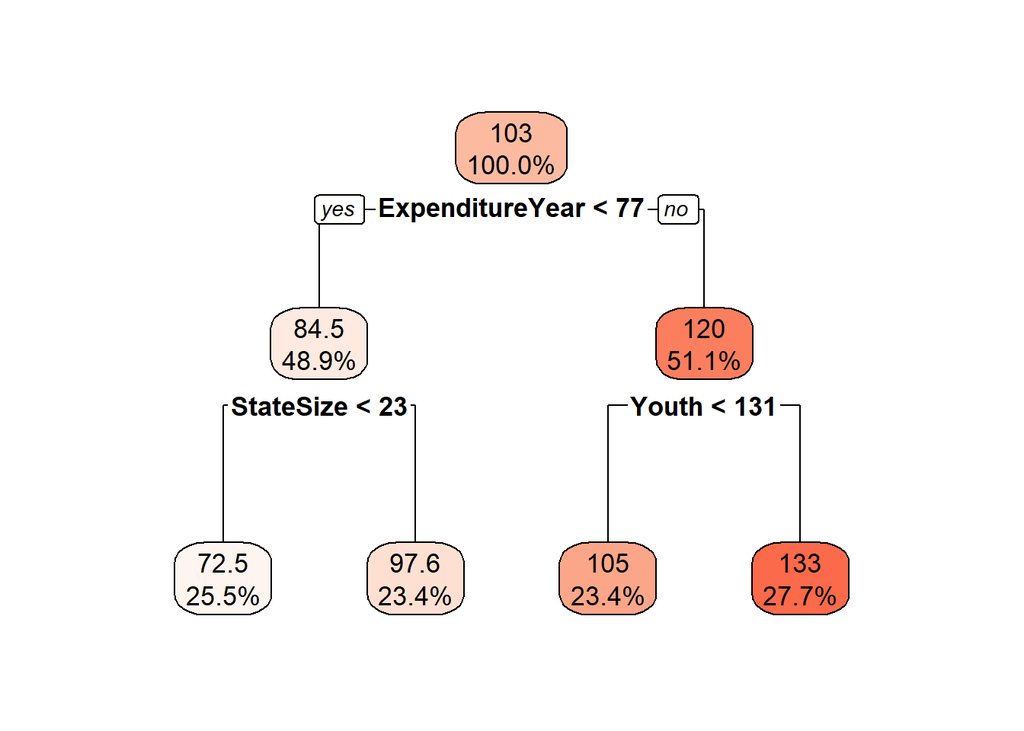

```r
rpart.plot(crime.m.rpart, digits = 3, fallen.leaves = TRUE,tweak=1.1, box.palette = "Reds")
```

##6 Wage, BelowWage and education were all excluded. This was done because rpart tries to balance the improvement gained by doing additional splits with the cost of the split. If an additional split does not decrease the overall lack of fit by the complexity parameter then the split is not done. You can change the tree formed by adding additional constraints like “minsplit” which changes the minimium number of observations for a split to be attempted.

##7

```r
crime.p.rpart <- predict(crime.m.rpart, crimedata10)
```

##8

```r
cor(crime.p.rpart, crimedata10[["CrimeRate"]],method="pearson")
```

```
## [1] 0.6175003
```

The correlation coefficent is 0.6175. ##9

```r
MAE <- function(actual, predicted)  {
  mean(abs(actual - predicted))
}

MAE(predicted = crime.p.rpart,actual = crimedata10[["CrimeRate"]])
```

```
## [1] 24.32924
```

It was okay at making predictions. Only being able to predict if a state was in the upper or lower half really. For a state roughly in the middle of the pack, 100, this model is on average off by ~25% thats enought for it to end up on either the high end or the low end of the spectrum. ##10

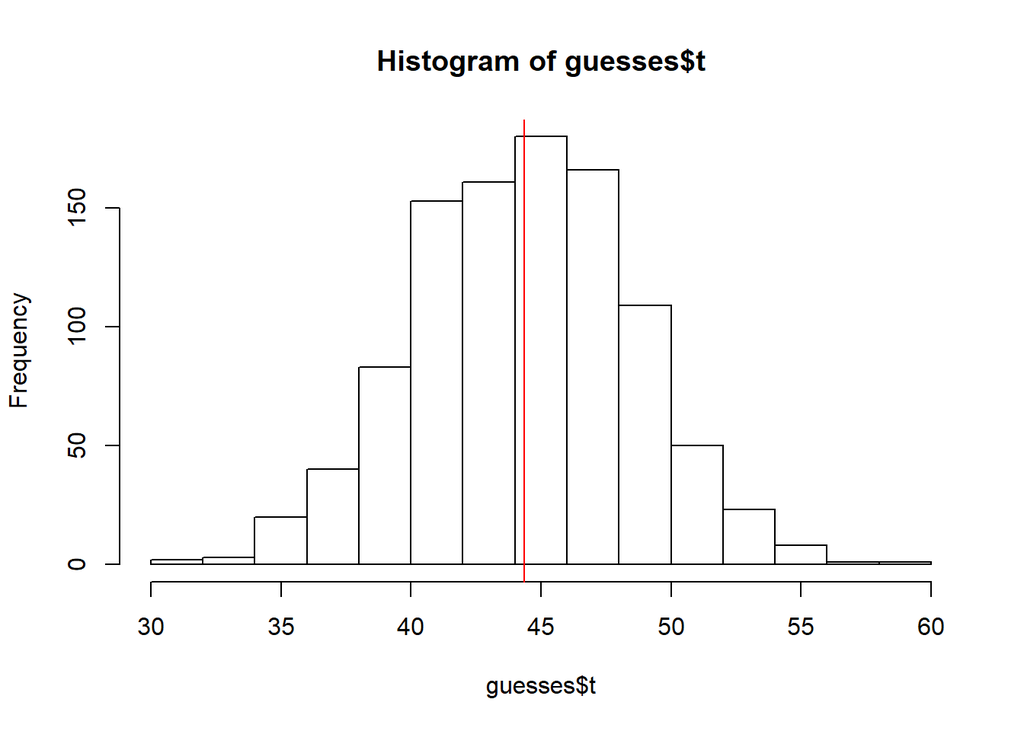

```r
#this removes the training data, so that you are left with the testing dataset
Crime10.CrimeRate.test=crimedata10[["CrimeRate"]]

#Let's save the actual wine qualities from the test dataset into a vector called actual
actual=Crime10.CrimeRate.test

#Here is a custom function that uses two variables, data and indices. The data will be the wine
#qualities from the test dataset. The indices will be randomly selected when using the boot function
#below. In essence, the boot function will randomly shuffle the wine quality data and then test
#against actual wine quality assignment. The MAE2 function will calculate the mean absolute error
#each time the data is shuffled.
MAE2 <- function(data,indices)  {
  d<-data[indices]
  return(mean(abs(actual - d)))
}

#Here we use the boot function to make our random "guesses." It will shuffle the wine quality
#data and calculate the mean absolute error using our MAE2 function. The R=1000 means it will
#do this 1000 times.
guesses=boot(data=Crime10.CrimeRate.test, statistic=MAE2, R=1000)

#Now, let's plot a histogram of mean absolute differences from the bootstrap and add a red
#line for the mean
{hist(guesses$t)
abline(v=mean(guesses$t),col="red")}
```

```r
mean(guesses$t)
```

```
## [1] 44.34504
```

```r
#Is our assignment with our model significantly different from that expected by chance?
p.value=length(which((guesses$t<0.5198)==T))/1000
p.value
```

```
## [1] 0
```

```r
t.test(guesses$t, mu=24.32924)
```

```
##
##  One Sample t-test
##
## data:  guesses$t
## t = 151.07, df = 999, p-value < 2.2e-16
## alternative hypothesis: true mean is not equal to 24.32924
## 95 percent confidence interval:
##  44.08503 44.60504
## sample estimates:
## mean of x
##  44.34504
```

##12 I don’t understand what your p-value code here does.

To test if the MAE from the model is different then by random chance I did a one sample t-test comparing the distribution of the random guesses to a mean of 24.32924 (the MAE of our model). This results in a p-value of <2.2e-16. indicating that the mean of the MAE of the random guesses is significantly different then the MAE of our model. This is confirmed by looking at the histogram and observing that 24.32924 would be far outside the expected results. Also backing this is the 95% confidence interval produced by the t-test showing that 24.32924 would be far outside the 95% confidence interval.